# Comcast Telecom Consumer Complaints

```python
import pandas as pd
import numpy as np
import matplotlib.pyplot as plt
%matplotlib inline
import seaborn as sns
import nltk
from wordcloud import WordCloud, STOPWORDS
```

Read the data

```python
datac = pd.read_csv('Comcast_telecom_complaints_data.csv')
```

```python
datac.info()
```

```
<class 'pandas.core.frame.DataFrame'>
RangeIndex: 2224 entries, 0 to 2223
Data columns (total 11 columns):
 #   Column                       Non-Null Count  Dtype
---  ------                       --------------  -----
 0   Ticket #                     2224 non-null   object
 1   Customer Complaint           2224 non-null   object
 2   Date                         2224 non-null   object
 3   Date_month_year              2224 non-null   object
 4   Time                         2224 non-null   object
 5   Received Via                 2224 non-null   object
 6   City                         2224 non-null   object
 7   State                        2224 non-null   object
 8   Zip code                     2224 non-null   int64
 9   Status                       2224 non-null   object
 10  Filing on Behalf of Someone  2224 non-null   object
dtypes: int64(1), object(10)
memory usage: 191.2+ KB
```

```python
datac.describe(include='all')
```

|  | Ticket # | Customer Complaint | Date | Date_month_year | Time | Received Via | City | State | Zip code | Status | Filing on Behalf of Someone |
| --- | --- | --- | --- | --- | --- | --- | --- | --- | --- | --- | --- |
| count | 2224 | 2224 | 2224 | 2224 | 2224 | 2224 | 2224 | 2224 | 2224.000000 | 2224 | 2224 |
| unique | 2224 | 1841 | 91 | 91 | 2190 | 2 | 928 | 43 | NaN | 4 | 2 |
| top | 359858 | Comcast | 24-06-15 | 24-Jun-15 | 5:32:37 PM | Customer Care Call | Atlanta | Georgia | NaN | Solved | No |
| freq | 1 | 83 | 218 | 218 | 2 | 1119 | 63 | 288 | NaN | 973 | 2021 |
| mean | NaN | NaN | NaN | NaN | NaN | NaN | NaN | NaN | 47994.393435 | NaN | NaN |
| std | NaN | NaN | NaN | NaN | NaN | NaN | NaN | NaN | 28885.279427 | NaN | NaN |
| min | NaN | NaN | NaN | NaN | NaN | NaN | NaN | NaN | 1075.000000 | NaN | NaN |
| 25% | NaN | NaN | NaN | NaN | NaN | NaN | NaN | NaN | 30056.500000 | NaN | NaN |
| 50% | NaN | NaN | NaN | NaN | NaN | NaN | NaN | NaN | 37211.000000 | NaN | NaN |
| 75% | NaN | NaN | NaN | NaN | NaN | NaN | NaN | NaN | 77058.750000 | NaN | NaN |
| max | NaN | NaN | NaN | NaN | NaN | NaN | NaN | NaN | 99223.000000 | NaN | NaN |

```python
datac.head()
```

|  | Ticket # | Customer Complaint | Date | Date_month_year | Time | Received Via | City | State | Zip code | Status | Filing on Behalf of Someone |
| --- | --- | --- | --- | --- | --- | --- | --- | --- | --- | --- | --- |
| 0 | 250635 | Comcast Cable Internet Speeds | 22-04-15 | 22-Apr-15 | 3:53:50 PM | Customer Care Call | Abingdon | Maryland | 21009 | Closed | No |
| 1 | 223441 | Payment disappear - service got disconnected | 04-08-15 | 04-Aug-15 | 10:22:56 AM | Internet | Acworth | Georgia | 30102 | Closed | No |
| 2 | 242732 | Speed and Service | 18-04-15 | 18-Apr-15 | 9:55:47 AM | Internet | Acworth | Georgia | 30101 | Closed | Yes |
| 3 | 277946 | Comcast Imposed a New Usage Cap of 300GB that ... | 05-07-15 | 05-Jul-15 | 11:59:35 AM | Internet | Acworth | Georgia | 30101 | Open | Yes |
| 4 | 307175 | Comcast not working and no service to boot | 26-05-15 | 26-May-15 | 1:25:26 PM | Internet | Acworth | Georgia | 30101 | Solved | No |

```python
datac.isnull().sum()
```

```
Ticket #                       0
Customer Complaint             0
Date                           0
Date_month_year                0
Time                           0
Received Via                   0
City                           0
State                          0
Zip code                       0
Status                         0
Filing on Behalf of Someone    0
dtype: int64
```

```python
datac[datac.duplicated()]
```

|  | Ticket # | Customer Complaint | Date | Date_month_year | Time | Received Via | City | State | Zip code | Status | Filing on Behalf of Someone |
| --- | --- | --- | --- | --- | --- | --- | --- | --- | --- | --- | --- |

TASK 1 - Provide the trend chart for the number of complaints at monthly and daily granularity levels

```python
datac['Date_month_year'] = pd.to_datetime(datac['Date_month_year'])
datac['Created_Month'] =  datac['Date_month_year'].apply(lambda x: x.month)
datac['Created_Day'] = datac['Date_month_year'].apply(lambda x: x.day)
datac['Created_Day of Week'] = datac['Date_month_year'].apply(lambda x: x.dayofweek)
```

Mapping the date , months and weeks

```python
dmap = {0:'Mon',1:'Tue',2:'Wed',3:'Thur',4:'Fri',5:'Sat',6:'Sun'}
datac['Created_Day of Week']=datac['Created_Day of Week'].map(dmap)
datac.head(5)
```

|  | Ticket # | Customer Complaint | Date | Date_month_year | Time | Received Via | City | State | Zip code | Status | Filing on Behalf of Someone | Created_Month | Created_Day | Created_Day of Week |
| --- | --- | --- | --- | --- | --- | --- | --- | --- | --- | --- | --- | --- | --- | --- |
| 0 | 250635 | Comcast Cable Internet Speeds | 22-04-15 | 2015-04-22 | 3:53:50 PM | Customer Care Call | Abingdon | Maryland | 21009 | Closed | No | 4 | 22 | Wed |
| 1 | 223441 | Payment disappear - service got disconnected | 04-08-15 | 2015-08-04 | 10:22:56 AM | Internet | Acworth | Georgia | 30102 | Closed | No | 8 | 4 | Tue |
| 2 | 242732 | Speed and Service | 18-04-15 | 2015-04-18 | 9:55:47 AM | Internet | Acworth | Georgia | 30101 | Closed | Yes | 4 | 18 | Sat |
| 3 | 277946 | Comcast Imposed a New Usage Cap of 300GB that ... | 05-07-15 | 2015-07-05 | 11:59:35 AM | Internet | Acworth | Georgia | 30101 | Open | Yes | 7 | 5 | Sun |
| 4 | 307175 | Comcast not working and no service to boot | 26-05-15 | 2015-05-26 | 1:25:26 PM | Internet | Acworth | Georgia | 30101 | Solved | No | 5 | 26 | Tue |

Number of complaints monthly granularity level

```
(0.0, 13.0)
```

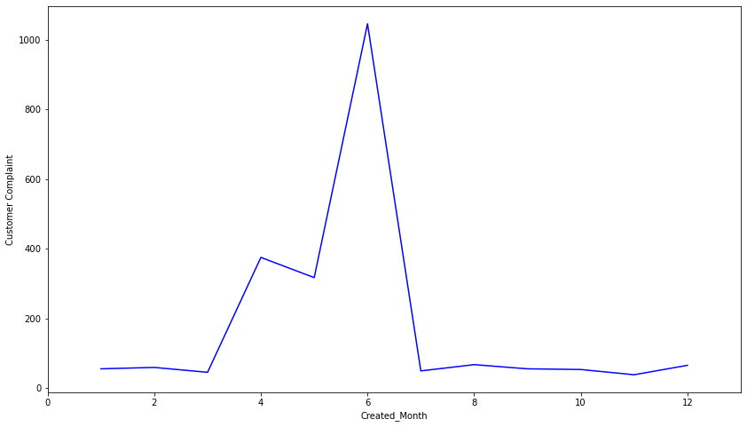

```python
plt.figure(figsize=(14,8))
bymonth = datac.groupby('Created_Month').count().reset_index()
lp = sns.lineplot(x='Created_Month', y= 'Customer Complaint', data = bymonth, sort=False,markers = "o",color='blue')
ax = lp.axes
ax.set_xlim(0,13)
# ax.annotate('Max complaints in Jun', color='red',
#             xy=(6, 1060), xycoords='data',
#             xytext=(0.8, 0.85), textcoords='axes fraction',
#             arrowprops=dict(facecolor='black', shrink=0.1),
#             horizontalalignment='right', verticalalignment='top')
```

We can see that the max complaints recieved is aroung June!

Number of complaints Daily granularity level

```
(0.0, 32.0)
```

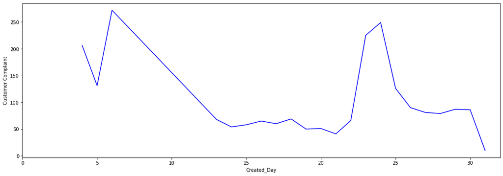

```python
plt.figure(figsize=(18,6))
byday = datac.groupby('Created_Day').count().reset_index()
lp = sns.lineplot(x='Created_Day', y= 'Customer Complaint', data = byday, sort=False, color = 'blue',markers = "o", )
ax = lp.axes
ax.set_xlim(0,32)
```

Number of complaints based on created day of the week

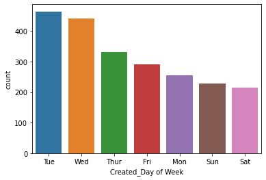

```python
sns.countplot(x='Created_Day of Week', data = datac,order=datac['Created_Day of Week'].value_counts().index)
```

Ok, they have recieved more number of complaints on Tuesday and Wednesday!

TASK 2 - Provide a table with the frequency of complaint types.

```python
datac['Customer Complaint'] = datac['Customer Complaint'].str.title()
CT_freq = datac['Customer Complaint'].value_counts()
CT_freq
```

```
Comcast                                                              102
Comcast Data Cap                                                      30
Comcast Internet                                                      29
Comcast Data Caps                                                     21
Comcast Billing                                                       18
                                                                    ...
Comcast!                                                               1
Comcast Xfintity Internet Data Caps                                    1
Paying For Hi Speed Internet 105 Mbps                                  1
Un Able To Access My Email Address After Relocae To A New Address      1
Data Usage Cap                                                         1
Name: Customer Complaint, Length: 1740, dtype: int64
```

Which complaint types are maximum i.e., around internet, network issues, or across any other domains.

Using NLTK to clean and get the frequently raised complaints!

```python
common_complaints = datac['Customer Complaint'].dropna().tolist()
common_complaints =''.join(common_complaints).lower()
```

```python
list_stops = ('Comcast','Now','Company','Day','Someone','Thing','Also','Got','Way','Call','Called','One','Said','Tell')
```

```python
for word in list_stops:
    STOPWORDS.add(word)
```

```python
wordcloud = WordCloud(stopwords=STOPWORDS,
                      background_color='white',
                      width=1200,
                      height=1000).generate(common_complaints)
```

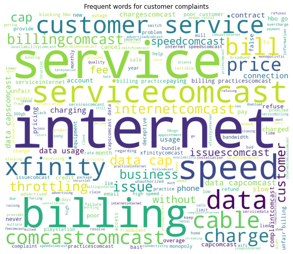

```python
plt.figure( figsize=(10,12) )
plt.imshow(wordcloud)
plt.title('Frequent words for customer complaints')
plt.axis('off')
plt.show()
```

Let's print the 3 top complaints accross different services - words_ - gives us string and it's associated frequency

```python
count = 0
for key,value in wordcloud.words_.items():
    print('Complaint Across: {} - {:.2f}'.format(key,value*100))
    count += 1
    if count > 2:
        break
```

```
Complaint Across: internet - 100.00
Complaint Across: service - 80.20
Complaint Across: billing - 45.39
```

TASK 3 - Create a new categorical variable with value as Open and Closed. Open & Pending is to be categorized as Open and Closed & Solved is to be categorized as Closed.

```python
datac['Highlevel_Status'] = ["Open" if Status=="Open" or Status=="Pending" else "Closed" for Status in datac["Status"]]
```

```python
datac['Highlevel_Status'].unique()
```

```
array(['Closed', 'Open'], dtype=object)
```

```python
datac['Highlevel_Status'].value_counts()
```

```
Closed    1707
Open       517
Name: Highlevel_Status, dtype: int64
```

TASK 4 - Provide state wise status of complaints in a stacked bar chart. Use the categorized variable from Q3.

```python
datac['State'] =datac['State'].str.title()
st_cmp = datac.groupby(['State','Highlevel_Status']).size().unstack().fillna(0)
```

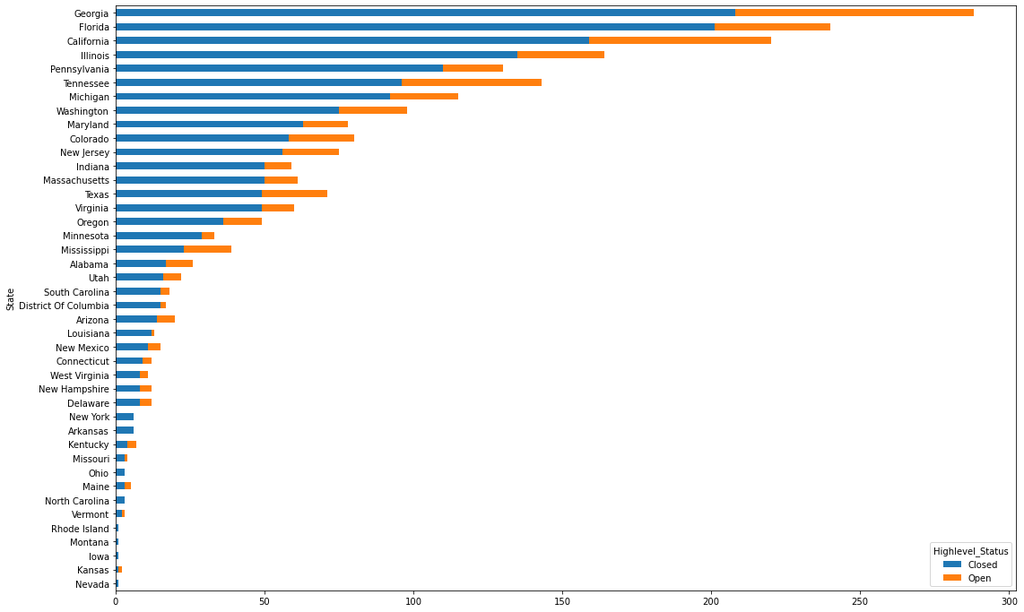

```python
st_cmp.sort_values('Closed',axis = 0,ascending=True).plot(kind="barh", figsize=(18,12), stacked=True)
```

TASK 5 - Which state has the maximum complaints Which state has the highest percentage of unresolved complaints

```python
datac.groupby(["State"]).size().sort_values(ascending=False).to_frame().rename({0: "Complaint count"}, axis=1)[:1]
```

| State | Complaint count |
| --- | --- |
| Georgia | 288 |

Georgia it is! Let's see open and closed status of tickets.

```python
cst = datac.groupby(["State","Highlevel_Status"]).size().unstack().fillna(0)
cst.sort_values('Closed',axis = 0,ascending=False)[:1]
```

| Highlevel_Status State | Closed | Open |
| --- | --- | --- |
| Georgia | 208.0 | 80.0 |

Which state has the highest percentage of unresolved complaints

```python
cst['Resolved_complaint_%'] = cst['Closed']/cst['Closed'].sum()*100
cst['Unresolved_complaint_%'] = cst['Open']/cst['Open'].sum()*100
```

```python
cst.sort_values('Unresolved_complaint_%',axis = 0,ascending=False)[:1]
```

| Highlevel_Status State | Closed | Open | Resolved_complaint_% | Unresolved_complaint_% |
| --- | --- | --- | --- | --- |
| Georgia | 208.0 | 80.0 | 12.18512 | 15.473888 |

Georgia!

TASK 6 - Provide the percentage of complaints resolved till date, which were received through the Internet and customer care calls.

```python
crs = datac.groupby(['Received Via','Highlevel_Status']).size().unstack().fillna(0)
crs['resolved'] = crs['Closed']/crs['Closed'].sum()*100
crs['resolved']
```

```
Received Via
Customer Care Call    50.615114
Internet              49.384886
Name: resolved, dtype: float64
```

```
 [Text(-0.021255489977842313, 1.0997946190747625, 'Closed'),
 [Text(-0.011593903624277625, 0.5998879740407794, '51%'),
```

[figure not shown]

```python
plt.pie(crs['resolved'], labels = crs, colors = ['red','green'], autopct='%.0f%%')
```